# basic_covariance_estimation

Eric Bridgeford

October 10, 2016

### Input

$t$: the number of timestep

$conditions$: conditions available

$onsets$[trials, conditions,t]: a spike train of condition onsets. takes a value of 1 for every time point where a particular condition begins.

$responsefx$[time]: a function that represents the expected response for every condition event.

### Output

$Wilcox$[condition,nroi,nroi]: a collection of p-values for each pair of conditions, where low p indicates a significant difference btwn the covariances of the conditions listed. For the simple case, we will only consider 2 conditions, and only consider each condition with respect to the overall (no within-condition combinations). Use the wilcoxon results from the overall (across all subjects).

## Algorithm Overview and Code Snippet

The Basic Covariance Estimation process we have completed is a simple experiment to consider covariance of different conditions in a MR experiment.

Essentially, this algorithm simply stems from the notion that, when we have a particular condition known to be occurring at a particular time point, we want to count that point when computing a covariance matrix for a particular experimental condition. We can modify and weight the algorithm by considering some time points more than others (ie, if we have an asymmetric response window, we might consider points 4 time steps from condition onset most, and timesteps around that time less).

```r
basic_covariance_estimation <- function(ts, onset_times, response) {

  # replace incorrect with overall, to get a better sampling of the data
  pi_vecs <- convolve_trial_onsets(onset_times, response)

  pi_vecs <- sapply(pi_vecs, function(sub) {
     sub[,3] <- rep(1, length=dim(sub)[1])
     return(sub)
  }, USE.NAMES=TRUE, simplify=FALSE)

  ordered_timesteps <- extract_timepoint_order(pi_vecs)

  ordered_timeseries <- extract_ordered_timeseries(ts, ordered_timesteps)

  # calculate correlation based on the condition, where time points
  # that should see a higher response are factored in most
  cond_ts <- conditional_covariance(ordered_timeseries, rank=FALSE)
  cov_cond <- cond_ts$cov
  mean_cond <- cond_ts$mean

  # reorder so that the conditions are our L1 keys, and subjects are L2
  cov_cond_reordered <- sapply(cond_key, function(cond) sapply(names(cov_cond), function(sub) X =
                                                                cov_cond[[sub]][[cond]],
                                                                USE.NAMES=TRUE, simplify=FALSE),
                                USE.NAMES=TRUE, simplify=FALSE)

  ## Wilcoxon Tests ----------------------------------------------------------
  cov_wilcox <- wilcox_test_conditions(cov_cond_reordered, subs, runs)

  wilcox_plots <- plot_corr_wilcox(cov_wilcox, textsize=10)
}
```

## Simulations

```r
one_iteration <- function(nt, nc, nroi, window, offset=4, overlap=4, verbose=1) {
  conditions <- array(0, dim=c(nt, nc)) # initialize empty condition vector
  for (cond in 1:nc) {
    conditions[seq((cond-1)*overlap + 1, nt, (nc-1)*overlap + offset), cond] <- 1
  }
  response <- convolve_conditions(conditions, window)


  latent_signal <- array(0, dim=c(dim(conditions)[2], nt, nroi))
  for (i in 1:dim(conditions)[2]) {
    positive_def = rnorm(nroi)
    positive_def = positive_def %*% t(positive_def)
    while (min(Re(eigen(positive_def)$values)) < 0) {
      positive_def = positive_def + diag(nroi)
    }
    latent_signal[i,,] <- mvrnorm(n=nt, mu=rnorm(nroi), Sigma=positive_def) # use random mu, random sigma for signals
  }
  # define the observed signal as a combination of the latent signals, where the contribution
  # of each is the pi vector at that time step
  observed_signal <- t(sapply(1:dim(latent_signal)[2], function(t) {
    apply(pi_vec[t,]*latent_signal[,t,], 2, sum)
  }))

  true_means <- apply(latent_signal, c(1,3), mean)
  true_cov <- sapply(1:dim(latent_signal)[1], function(x) cov(latent_signal[x,,]), simplify='array')

  pi_vec <- ceiling(pi_vec)
  pi_vec <- split(pi_vec, rep(1:ncol(pi_vec), each = nrow(pi_vec)))

  ordered_timesteps <- timepoint_order(pi_vec)

  ordered_timeseries <- get_ordered_timeseries(observed_signal, ordered_timesteps)

  predicted_cov = conditional_cov(ordered_timeseries)

  predicted_mean = conditional_mean(ordered_timeseries)

  pred_cov <- sapply(predicted_cov, function(x) x, USE.NAMES=FALSE, simplify='array')

  covs <- abind(true_cov, pred_cov, along=3)

  trials <- c()
  labels <- c()
  for (i in 1:nc) {
    trials <- c(trials, paste(i))
    labels <- c(labels, paste(i, "true", sep=" "))
  }
  for (i in 1:nc) {
    trials <- c(trials, paste(i))
    labels <- c(labels, paste(i, "predict", sep=" "))
  }

  Dmtx <- distance(covs)
  mnr <- mnr(rdf(Dmtx, trials))

  D <- melt(Dmtx)
  for (i in 1:length(trials)) {
    D[D$Var1 == i,]$Var1 <- labels[i]
    D[D$Var2 == i,]$Var2 <- labels[i]
  }
  error <- mean(sapply(unique(trials), function(x) {
    varas <- which(trials == x)
    return(Dmtx[varas[1], varas[2]])
  }))

}
```

### Simulations we can Handle

In particular, this algorithm should excel when we have perfectly interleaved timeseries based on the response condition. For example, if we have source covariance/mean that every 4 timesteps is sampled from, and we alternate 4 timestep windows with another source covariance/mean, we should be able to perfectly recover the covariance and mean of each timeseries.

### Perfect Simulation

In a perfect scenario, the response of each condition will be exactly perfectly distinguishable from the other condition. Here, we can see from the top multiplot that this is clearly the case, as our conditions are “interleaved”.

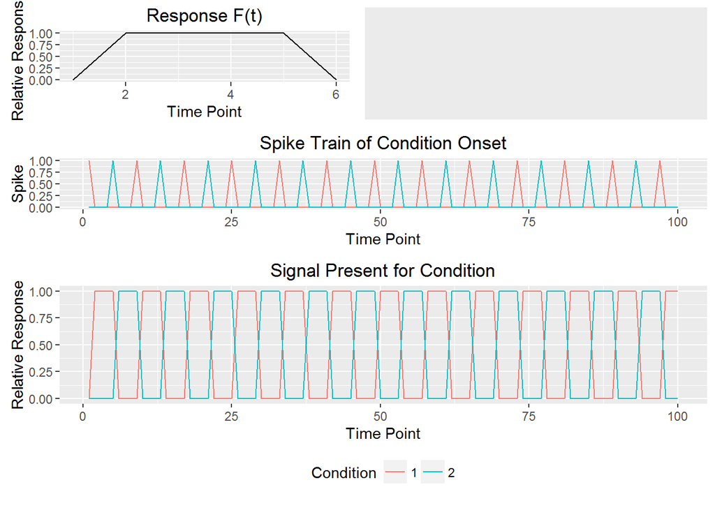

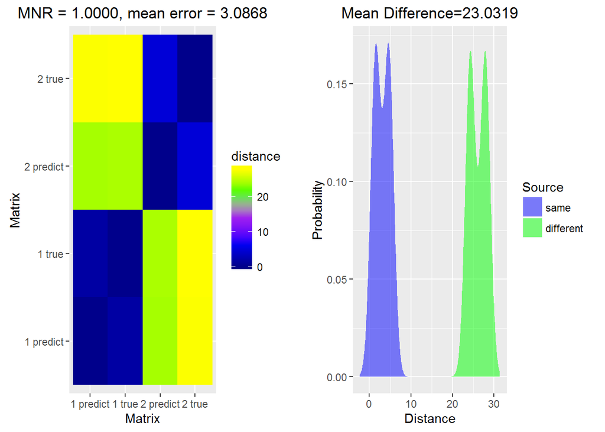

```r
  one_iteration(100, 2, 10, array(c(0, 1, 1, 1, 1, 0)), offset=4, overlap=4, verbose=1)
```

### Good Simulation

As we can see, our method performs perfectly. Let’s try another situation, this one a little harder. We move over the overlap a little bit, such that the trials overlap slightly, and we can see that our prediction suffers as a result. However, the difference is not significant enough to really reduce our prediction power, and we still get a very good estimate:

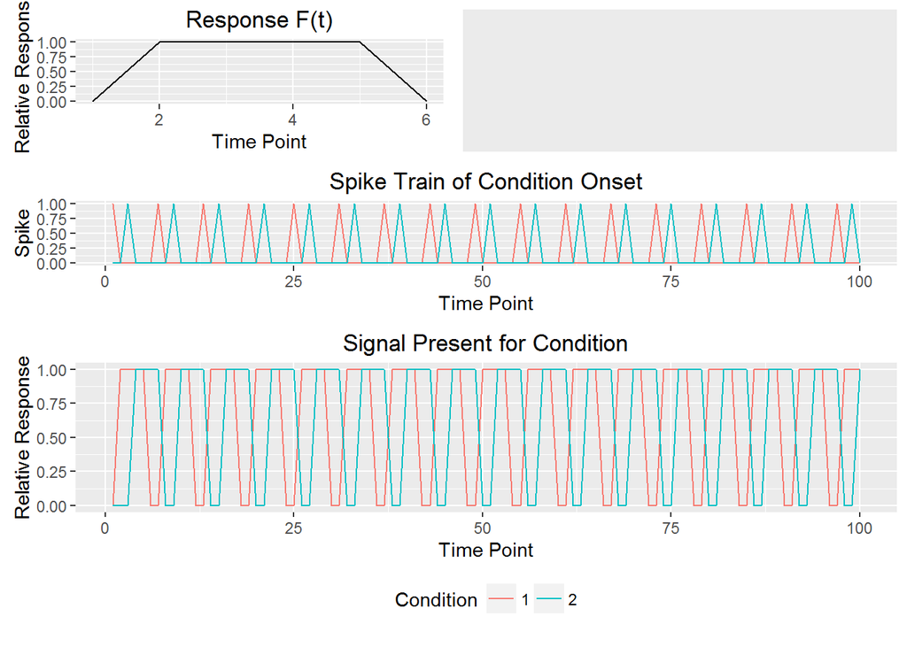

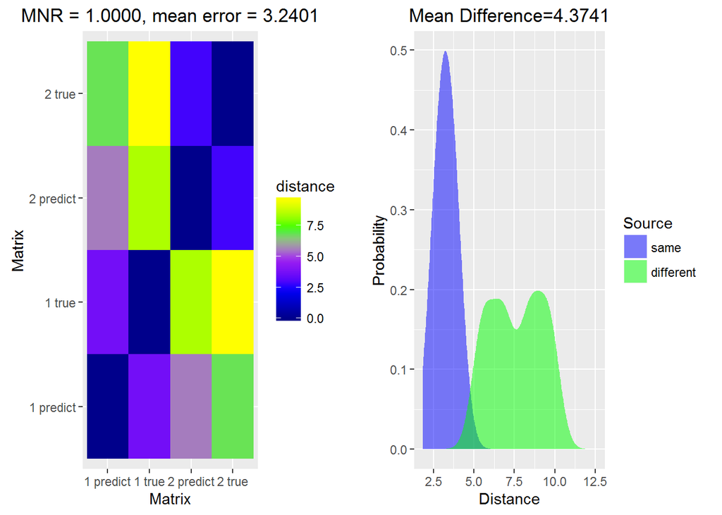

```r
  one_iteration(100, 2, 10, array(c(0, 1, 1, 1, 1, 0)), offset=4, overlap=2, verbose=1)
```

### Simulations we can’t Handle

Conversely from the above described scenario, this algorithm should perform incredibly poorly when we have overlapping time windows. For example, if we have one source covariance/mean that is present exactly when another source covariance/mean is present, we will be unable to truly recover the covariances/means for either of the sources.

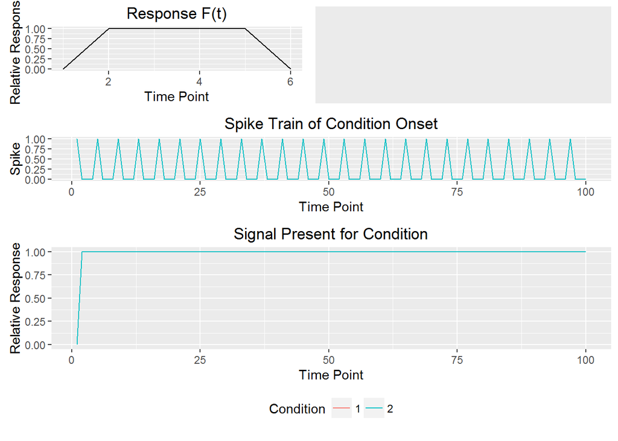

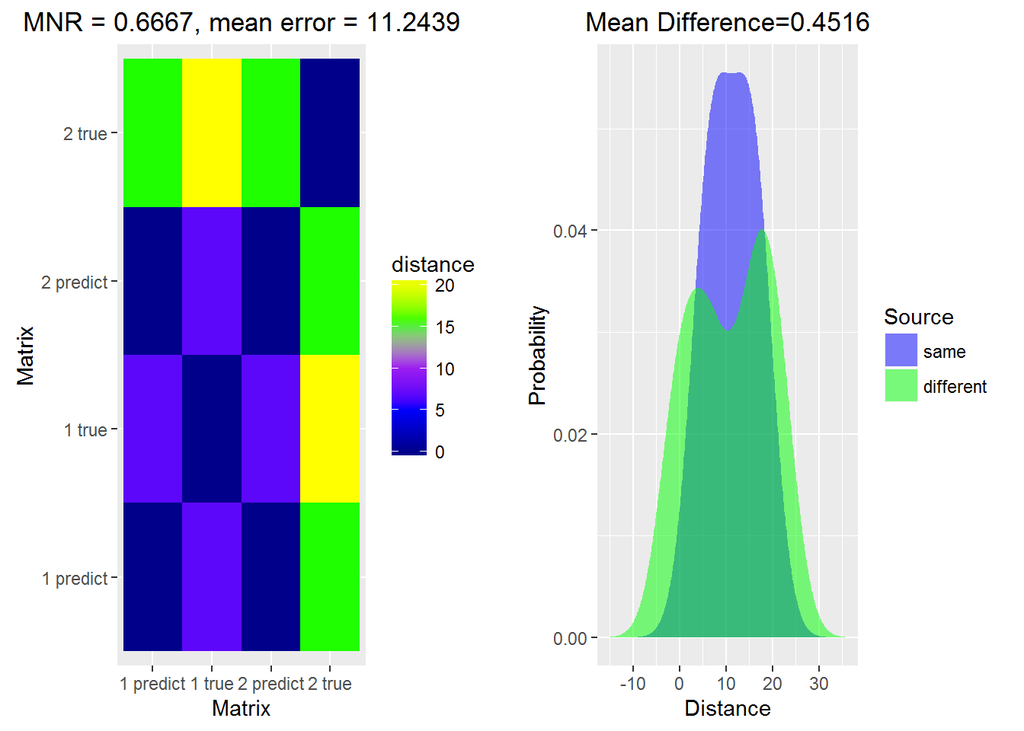

```r
  one_iteration(100, 2, 10, array(c(0, 1, 1, 1, 1, 0)), offset=4, overlap=0, verbose=1)
```

As we can see above, the simulation performs poorly as expected. We can’t even see our timepoints for one of the conditions because they overlap with the other one perfectly.